# 2.8 Practical: nonlinear model - functional response

Benjamin Rosenbaum

October 20, 2020

# Model

In feeding interactions between a predator and a prey species, the functional response $F$ describes the density-dependent feeding rate of the consumer.

The number of prey individuals a predator can consume in a given time does not grow proportionally with increasing prey availability, but reaches a saturation.

(A predator can only consume a limited number of prey in a given time.)

Mathematically, $F(N)$ is parameterised by attack rate $a$ and handling time $h$

$$F(N) = \frac{aN}{1+ahN}$$

$a$ descibes the slope of the curve in the origin, while the saturation (maximum feeding rate) is given by $\frac{1}{h}$.

This is a nonlinear function and we can’t use `lm()` to fit it.

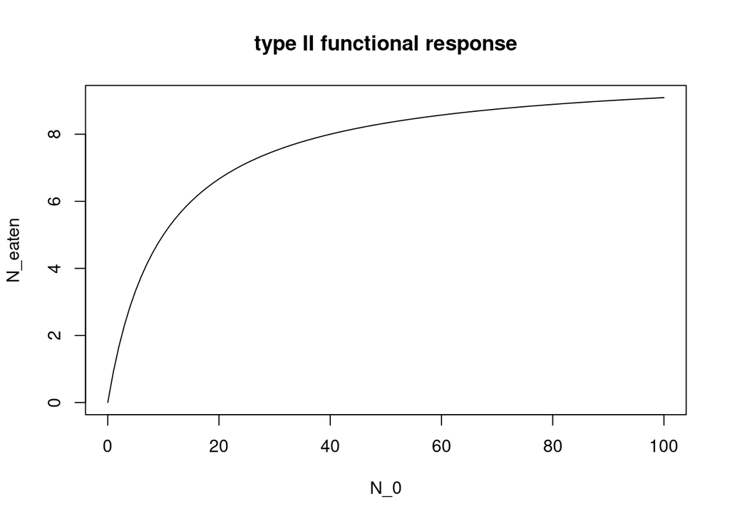

```r
a=1
h=0.1
curve(a*x/(1+a*h*x), from=0, to=100,
      xlab="N_0", ylab="N_eaten", main="type II functional response")
```

# Setup

```r
rm(list=ls())
library(rstan)
library(coda)
```

```r
library(BayesianTools)
setwd("~/Nextcloud/teaching Bayes")

rstan_options(auto_write = TRUE)
options(mc.cores = 3)
```

# Read dataset

We read data from a feeding experiment.

Rosenbaum B, Rall BC. Fitting functional responses: Direct parameter estimation by simulating differential equations. Methods Ecol Evol. 2018;9:2076–2090. https://doi.org/10.1111/2041-210X.13039

oringinal data from: Vucic‐Pestic, O. , Rall, B. C., Kalinkat, G. and Brose, U. (2010), Allometric functional response model: body masses constrain interaction strengths. Journal of Animal Ecology, 79: 249-256. doi:10.1111/j.1365-2656.2009.01622.x

In repeated feeding trials with varying number of initial prey, the number of eaten prey was counted

```r
# df = read.csv("https://datadryad.org/bitstream/handle/10255/dryad.181841/data_vucic-pestic_manual.csv")
df = read.csv("data/data_vucic-pestic_manual.csv")
head(df)
```

```
##   N0 Neaten
## 1  1      0
## 2  1      0
## 3  1      0
## 4  1      0
## 5  1      0
## 6  1      0
```

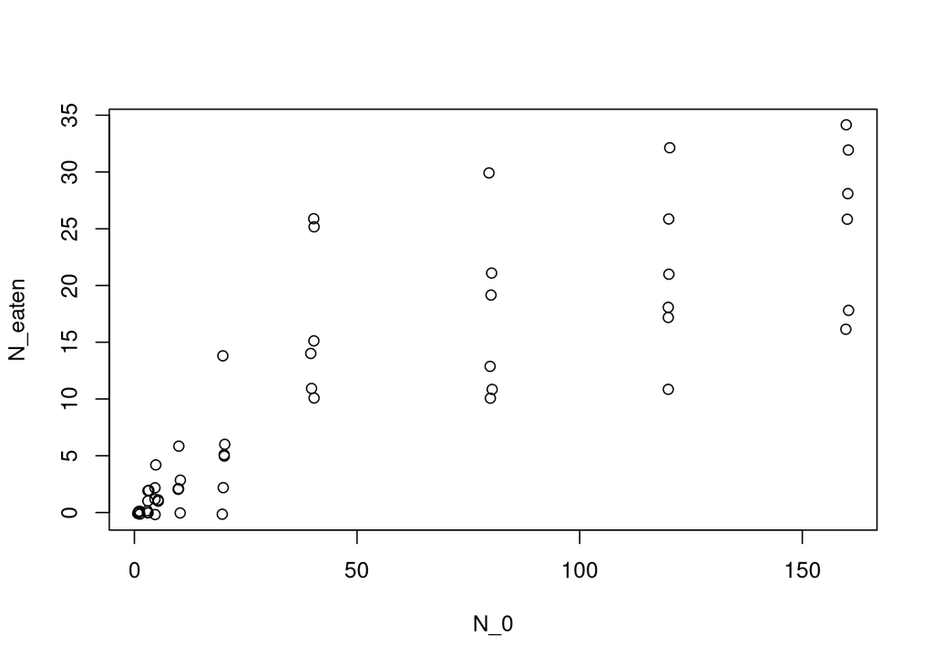

```r
plot(jitter(df[,1]), jitter(df[,2]),xlab="N_0", ylab="N_eaten")
```

Let’s assume that the experiment was supervised and each eaten prey item was replaced immediately, such that the number of available prey was constant during the course of the experiment.

(Otherwise we would have to correct for prey depletion, see Rosenbaum & Rall, 2018).

The deterministic model is defined by the functional response $F(N)$.

This is count data, so we use a poisson distribution for the stochastic part.

$$\begin{aligned}
y_i & \sim \text{poisson}(F_i) \\
F_i &= \frac{aN_i}{1+ahN_i}
\end{aligned}$$

# Stan code and fitting

```r
data = list(n = nrow(df),
            x = df$N0,
            y = df$Neaten)

stan_code = '
data {
  int n;
  int x[n];
  int y[n];
}
parameters {
  real<lower=0> a;
  real<lower=0> h;
}
model {
  // priors
  a ~ normal(0, 10);
  h ~ normal(0, 1);
  // likelihood
  for(i in 1:n){
    y[i] ~ poisson( a*x[i]/(1.0+a*h*x[i]) );
  }
}
'

stan_model = stan_model(model_code=stan_code)
# save(stan_model, file="stan_model.RData")
# load("stan_model.RData")

fit  = sampling(stan_model,
                data=data,
                chains=3,
                iter=2000,
                warmup=1000
)
```

```r
print(fit, digits=3, probs=c(0.025, 0.975))
```

```
## Inference for Stan model: 9851d626b23d5eb574cf1138e3094434.
## 3 chains, each with iter=2000; warmup=1000; thin=1;
## post-warmup draws per chain=1000, total post-warmup draws=3000.
##
##         mean se_mean    sd    2.5%   97.5% n_eff  Rhat
## a      0.390   0.001 0.044   0.313   0.487   925 1.002
## h      0.023   0.000 0.003   0.016   0.030  1022 1.002
## lp__ 968.715   0.033 1.014 966.047 969.724   941 1.000
##
## Samples were drawn using NUTS(diag_e) at Wed Oct 14 10:48:40 2020.
## For each parameter, n_eff is a crude measure of effective sample size,
## and Rhat is the potential scale reduction factor on split chains (at
## convergence, Rhat=1).
```

```
## ci_level: 0.8 (80% intervals)
```

```
## outer_level: 0.95 (95% intervals)
```

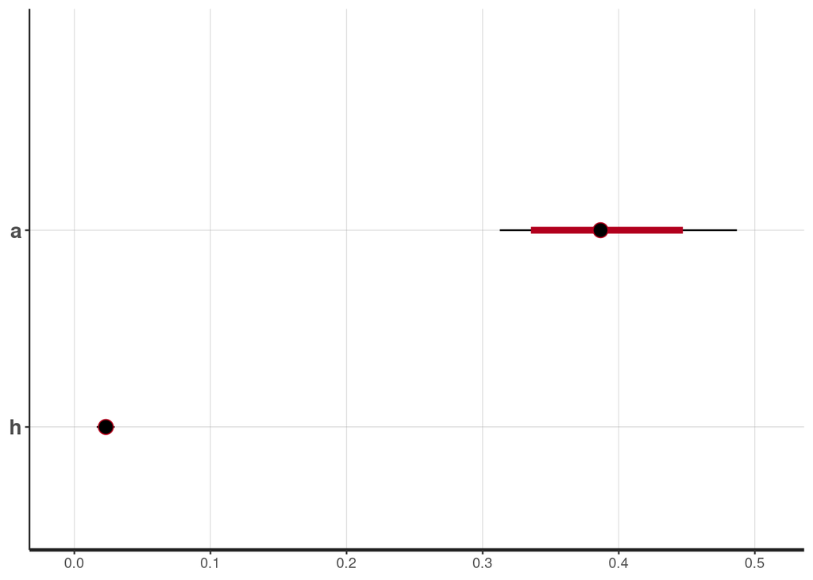

```r
plot(fit)
```

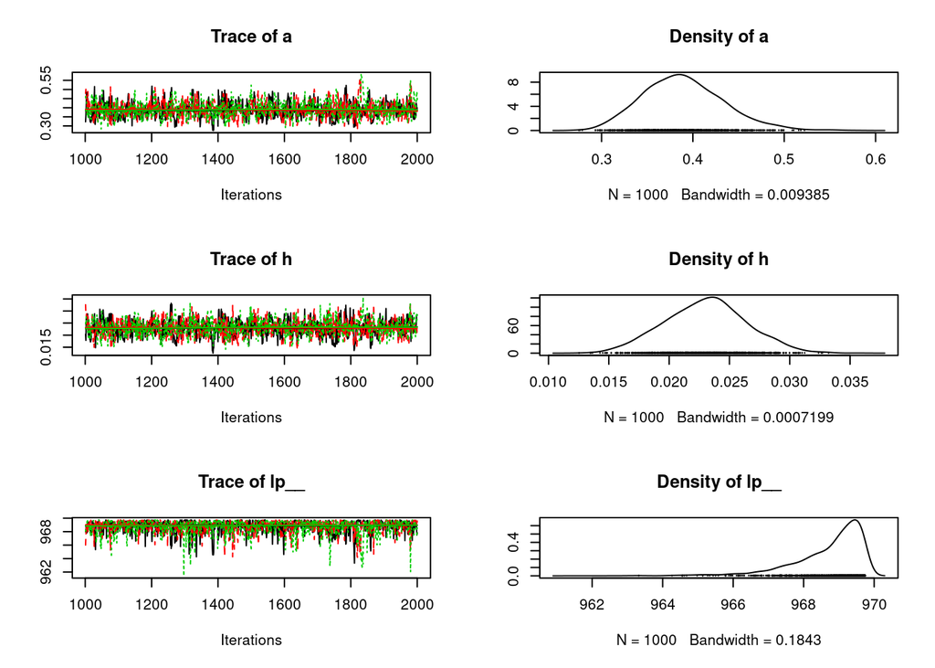

```r
plot(As.mcmc.list(fit)) # from coda package
```

```r
posterior=as.matrix(fit)

head(posterior)
```

```
##           parameters
## iterations         a          h     lp__
##       [1,] 0.3228025 0.02038087 967.9757
##       [2,] 0.3562186 0.01783348 968.0586
##       [3,] 0.4128849 0.02712507 968.9882
##       [4,] 0.4848034 0.02749363 967.8226
##       [5,] 0.4848034 0.02749363 967.8226
##       [6,] 0.4676750 0.02677551 968.3883
```

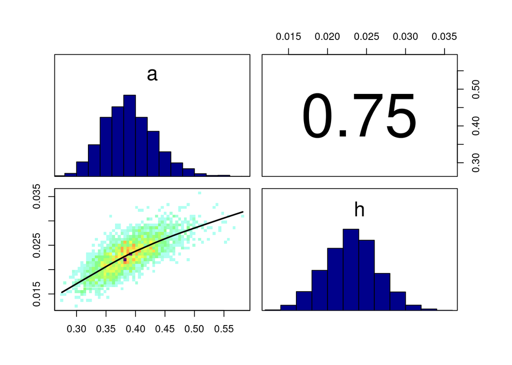

```r
correlationPlot(posterior[,1:2], thin=1)
```

# Predictions

90% credible intervals for the deterministic part of the model

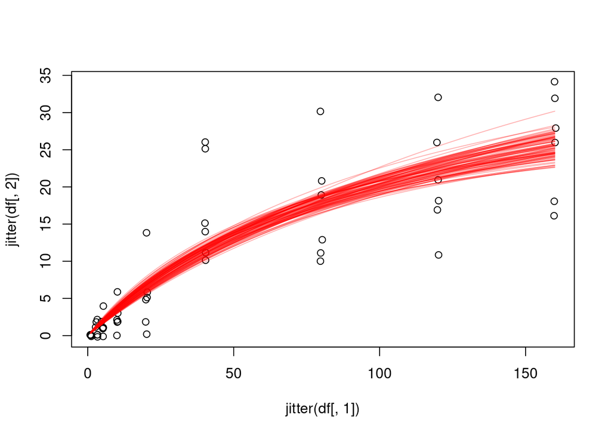

```r
x.pred = seq(from=1, to=max(data$x), by=1)
y.cred = matrix(0, nrow=nrow(posterior), ncol=length(x.pred))

for(i in 1:nrow(posterior)){
  y.cred[i, ] = posterior[i,"a"]*x.pred / (1+posterior[i,"a"]*posterior[i,"h"]*x.pred)
}

plot(jitter(df[,1]), jitter(df[,2]))

for(i in 1:100){
  lines(x.pred, y.cred[i, ], col=adjustcolor("red", alpha.f=0.3))
}
```

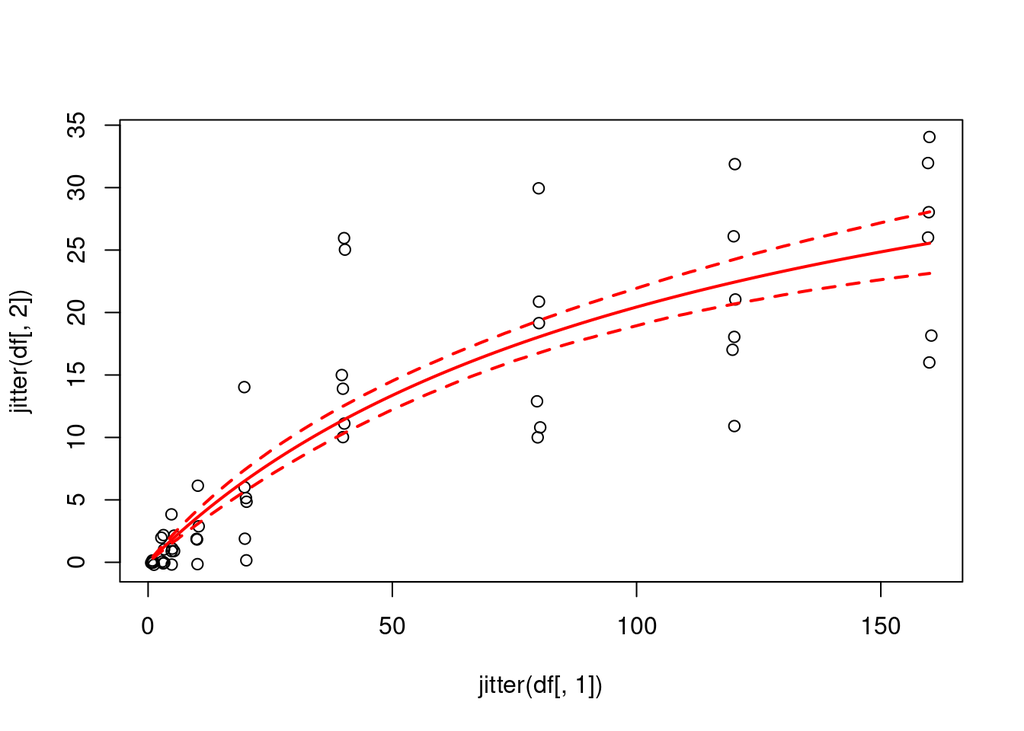

```r
plot(jitter(df[,1]), jitter(df[,2]))

y.cred.mean = apply(y.cred, 2, function(x) mean(x))
lines(x.pred, y.cred.mean, col="red", lwd=2)

y.cred.q05 = apply(y.cred, 2, function(x) quantile(x, probs=0.05))
lines(x.pred, y.cred.q05, col="red", lwd=2, lty=2)

y.cred.q95 = apply(y.cred, 2, function(x) quantile(x, probs=0.95))
lines(x.pred, y.cred.q95, col="red", lwd=2, lty=2)
```

90% predictions intervals for the data including stochastic part of the model

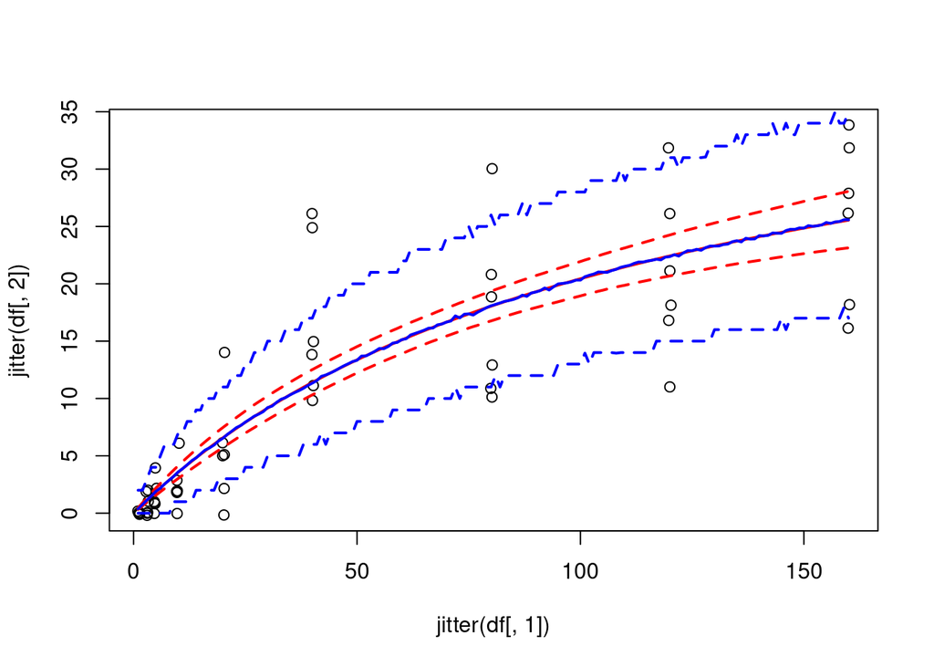

```r
y.pred = matrix(0, nrow=nrow(posterior), ncol=length(x.pred))
for(i in 1:nrow(posterior)){
  y.pred[i, ] = rpois(n=length(x.pred), lambda=y.cred[i, ])
}

plot(jitter(df[,1]), jitter(df[,2]))

lines(x.pred, y.cred.mean, col="red", lwd=2)
lines(x.pred, y.cred.q05, col="red", lwd=2, lty=2)
lines(x.pred, y.cred.q95, col="red", lwd=2, lty=2)

y.pred.mean = apply(y.pred, 2, function(x) mean(x))
lines(x.pred, y.pred.mean, col="blue", lwd=2)

y.pred.q05 = apply(y.pred, 2, function(x) quantile(x, probs=0.05))
lines(x.pred, y.pred.q05, col="blue", lwd=2, lty=2)

y.pred.q95 = apply(y.pred, 2, function(x) quantile(x, probs=0.95))
lines(x.pred, y.pred.q95, col="blue", lwd=2, lty=2)
```

Variation in observed data increases with $N$, this variation is also captured in the predicted values.